# Andmekvaliteedi hindamine, andmelünkade analüüs

Indrek Soidla

9 2 2023

## Pakettide ja andmete laadimine

Laeme sisse vajalikud paketid.

```r
library(haven)
library(foreign)
library(tidyverse)
library(summarytools)
library(naniar)
library(finalfit)
```

Laeme sisse Euroopa Sotsiaaluuringu Eesti 9. laine andmed (2018).

```r
ee9 <- read_sav("data/ESS9EE.sav")
```

Kui Maciga tekib probleeme andmete sisselugemisel või nende töötlemisel, võib proovida andmed sisse lugeda paketiga `foreign`.

```r
# ee9 <- read.spss("data/ESS9EE.sav", to.data.frame = TRUE, use.value.labels = FALSE)
```

Eraldame meile huvipakkuvad tunnused.

```r
andmed <- ee9 %>%
  select(stflife, lrscale, imsmetn, imdfetn, impcntr, imbgeco, imueclt, imwbcnt, rlgdgr, brncntr, gndr, agea, eduyrs)
```

## Põhiline ülevaade andmestiku lünklikkusest

Vaatame andmekirjeldust, et näha, mis tunnused andmestikus on ja millised on nende võimalikud väärtused.

```r
str(andmed)
```

```
## tibble [1,904 x 13] (S3: tbl_df/tbl/data.frame)
##  $ stflife: dbl+lbl [1:1904] 10,  9,  5,  5,  4,  5,  5,  7,  5,  6, 10,  9,  4,  ...
##    ..@ label        : chr "How satisfied with life as a whole"
##    ..@ format.spss  : chr "F2.0"
##    ..@ display_width: int 9
##    ..@ labels       : Named num [1:14] 0 1 2 3 4 5 6 7 8 9 ...
##    .. ..- attr(*, "names")= chr [1:14] "Extremely dissatisfied" "1" "2" "3" ...
##  $ lrscale: dbl+lbl [1:1904]  5,  5,  8,  5, NA, NA,  8,  5,  8,  5, NA,  3,  2,  ...
##    ..@ label        : chr "Placement on left right scale"
##    ..@ format.spss  : chr "F2.0"
##    ..@ display_width: int 9
##    ..@ labels       : Named num [1:14] 0 1 2 3 4 5 6 7 8 9 ...
##    .. ..- attr(*, "names")= chr [1:14] "Left" "1" "2" "3" ...
##  $ imsmetn: dbl+lbl [1:1904]  2,  2,  2,  3,  2,  1,  1,  3,  2,  2,  2,  2,  3,  ...
##    ..@ label        : chr "Allow many/few immigrants of same race/ethnic group as majority"
##    ..@ format.spss  : chr "F1.0"
##    ..@ display_width: int 9
##    ..@ labels       : Named num [1:7] 1 2 3 4 7 8 9
##    .. ..- attr(*, "names")= chr [1:7] "Allow many to come and live here" "Allow some" "Allow a few" "Allow none" ...
##  $ imdfetn: dbl+lbl [1:1904]  3,  3,  3,  3,  2,  3,  1,  2,  2,  2,  3,  2,  3,  ...
##    ..@ label        : chr "Allow many/few immigrants of different race/ethnic group from majority"
##    ..@ format.spss  : chr "F1.0"
##    ..@ display_width: int 9
##    ..@ labels       : Named num [1:7] 1 2 3 4 7 8 9
##    .. ..- attr(*, "names")= chr [1:7] "Allow many to come and live here" "Allow some" "Allow a few" "Allow none" ...
##  $ impcntr: dbl+lbl [1:1904]  4,  3,  3,  3,  2,  3,  3,  4,  2,  3,  3,  3,  3,  ...
##    ..@ label        : chr "Allow many/few immigrants from poorer countries outside Europe"
##    ..@ format.spss  : chr "F1.0"
##    ..@ display_width: int 9
##    ..@ labels       : Named num [1:7] 1 2 3 4 7 8 9
##    .. ..- attr(*, "names")= chr [1:7] "Allow many to come and live here" "Allow some" "Allow a few" "Allow none" ...
##  $ imbgeco: dbl+lbl [1:1904] 3, 5, 5, 2, 7, 5, 7, 5, 6, 4, 4, 5, 8, 6, 6, 3, 5, 7,...
##    ..@ label        : chr "Immigration bad or good for country's economy"
##    ..@ format.spss  : chr "F2.0"
##    ..@ display_width: int 9
##    ..@ labels       : Named num [1:14] 0 1 2 3 4 5 6 7 8 9 ...
##    .. ..- attr(*, "names")= chr [1:14] "Bad for the economy" "1" "2" "3" ...
##  $ imueclt: dbl+lbl [1:1904]  3,  5,  2, 10,  8, 10,  9,  9,  6,  3,  8,  5,  5,  ...
##    ..@ label        : chr "Country's cultural life undermined or enriched by immigrants"
##    ..@ format.spss  : chr "F2.0"
```

[output cut: 22 more lines]

```
##    ..@ format.spss  : chr "F1.0"
##    ..@ display_width: int 6
##    ..@ labels       : Named num [1:3] 1 2 9
##    .. ..- attr(*, "names")= chr [1:3] "Male" "Female" "No answer"
##  $ agea   : dbl+lbl [1:1904] 37, 72, 57, 56, 53, 35, 75, 72, 28, 28, 85, 18, 47, 5...
##    ..@ label        : chr "Age of respondent, calculated"
##    ..@ format.spss  : chr "F4.0"
##    ..@ display_width: int 6
##    ..@ labels       : Named num 999
##    .. ..- attr(*, "names")= chr "Not available"
##  $ eduyrs : dbl+lbl [1:1904] 16, 17, 11, 15,  8, 14, 11, 11, 12, 12, 10, 11, 11, 1...
##    ..@ label      : chr "Years of full-time education completed"
##    ..@ format.spss: chr "F2.0"
##    ..@ labels     : Named num [1:3] 77 88 99
##    .. ..- attr(*, "names")= chr [1:3] "Refusal" "Don't know" "No answer"
```

```r
sum(complete.cases(andmed)) # Täielikult mõõdetud indiviidide arv
```

```
## [1] 1660
```

```r
sum(!complete.cases(andmed)) # Andmelünkadega indiviidide arv ehk indiviidide arv, kellel on vähemalt ühes tunnuses andmelünk
```

```
## [1] 244
```

```r
sum(!complete.cases(andmed)) / nrow(andmed) # Andmelünkadega indiviidide osakaal andmestikus
```

```
## [1] 0.1281513
```

Uurime lünklikkust veel lähemalt. Mida näitavad järgnevad kokkuvõtted andmetest?

```r
miss_var_summary(andmed)
```

```
## # A tibble: 13 x 3
##    variable n_miss pct_miss
##    <chr>     <int>    <dbl>
##  1 lrscale     193  10.1
##  2 imbgeco      44   2.31
##  3 imwbcnt      37   1.94
##  4 imueclt      30   1.58
##  5 impcntr      13   0.683
##  6 imdfetn      11   0.578
##  7 imsmetn       9   0.473
##  8 rlgdgr        6   0.315
##  9 stflife       1   0.0525
## 10 brncntr       0   0
## 11 gndr          0   0
## 12 agea          0   0
## 13 eduyrs        0   0
```

```r
miss_var_table(andmed)
```

```
## # A tibble: 10 x 3
##    n_miss_in_var n_vars pct_vars
##            <int>  <int>    <dbl>
##  1             0      4    30.8
##  2             1      1     7.69
##  3             6      1     7.69
##  4             9      1     7.69
##  5            11      1     7.69
##  6            13      1     7.69
##  7            30      1     7.69
##  8            37      1     7.69
##  9            44      1     7.69
## 10           193      1     7.69
```

```r
miss_case_table(andmed)
```

```
## # A tibble: 8 x 3
##   n_miss_in_case n_cases pct_cases
##            <int>   <int>     <dbl>
## 1              0    1660   87.2
## 2              1     189    9.93
## 3              2      34    1.79
## 4              3       8    0.420
## 5              4       6    0.315
## 6              5       4    0.210
## 7              6       2    0.105
## 8              7       1    0.0525
```

```r
miss_case_summary(andmed)
```

```
## # A tibble: 1,904 x 3
##     case n_miss pct_miss
##    <int>  <int>    <dbl>
##  1  1270      7     53.8
##  2   179      6     46.2
##  3   255      6     46.2
##  4    32      5     38.5
##  5   482      5     38.5
##  6  1163      5     38.5
##  7  1729      5     38.5
##  8    80      4     30.8
##  9   362      4     30.8
## 10   372      4     30.8
## # ... with 1,894 more rows
```

`naniar` töötab koostöös `dplyr`iga, nii et saame hõlpsalt esitada samu kokkuvõtteid grupiti, nt uurida lünklikkust võrdlevalt meeste ja naiste seas.

```r
andmed %>%
  group_by(gndr) %>%
  miss_var_summary() %>%
  print(n = Inf)
```

```
## # A tibble: 24 x 4
## # Groups:   gndr [2]
##          gndr variable n_miss pct_miss
##     <dbl+lbl> <chr>     <int>    <dbl>
##  1 2 [Female] lrscale     123  11.5
##  2 2 [Female] imbgeco      30   2.81
##  3 2 [Female] imwbcnt      26   2.44
##  4 2 [Female] imueclt      20   1.87
##  5 2 [Female] imdfetn       9   0.843
##  6 2 [Female] impcntr       9   0.843
##  7 2 [Female] imsmetn       7   0.656
##  8 2 [Female] rlgdgr        4   0.375
##  9 2 [Female] stflife       1   0.0937
## 10 2 [Female] brncntr       0   0
## 11 2 [Female] agea          0   0
## 12 2 [Female] eduyrs        0   0
## 13 1 [Male]   lrscale      70   8.36
## 14 1 [Male]   imbgeco      14   1.67
## 15 1 [Male]   imwbcnt      11   1.31
## 16 1 [Male]   imueclt      10   1.19
## 17 1 [Male]   impcntr       4   0.478
## 18 1 [Male]   imsmetn       2   0.239
## 19 1 [Male]   imdfetn       2   0.239
## 20 1 [Male]   rlgdgr        2   0.239
## 21 1 [Male]   stflife       0   0
## 22 1 [Male]   brncntr       0   0
## 23 1 [Male]   agea          0   0
## 24 1 [Male]   eduyrs        0   0
```

```r
andmed %>%
  group_by(gndr) %>%
  miss_case_table() %>%
  print(n = Inf)
```

```
## # A tibble: 13 x 4
## # Groups:   gndr [2]
##          gndr n_miss_in_case n_cases pct_cases
##     <dbl+lbl>          <int>   <int>     <dbl>
##  1 2 [Female]              0     912   85.5
##  2 2 [Female]              1     120   11.2
##  3 2 [Female]              2      18    1.69
##  4 2 [Female]              3       6    0.562
##  5 2 [Female]              4       4    0.375
##  6 2 [Female]              5       4    0.375
##  7 2 [Female]              6       2    0.187
##  8 2 [Female]              7       1    0.0937
##  9 1 [Male]                0     748   89.4
## 10 1 [Male]                1      69    8.24
## 11 1 [Male]                2      16    1.91
## 12 1 [Male]                3       2    0.239
## 13 1 [Male]                4       2    0.239
```

## Visuaalne ülevaade lünklikkusest

Pilt ütlevat rohkem kui sada sõna (eeldusel, et oskame pilti adekvaatselt tõlgendada). Teeme siis lünklikkusest kiirema ülevaate saamiseks pilte (st jooniseid). Mida järgnevatel joonistel kujutatakse?

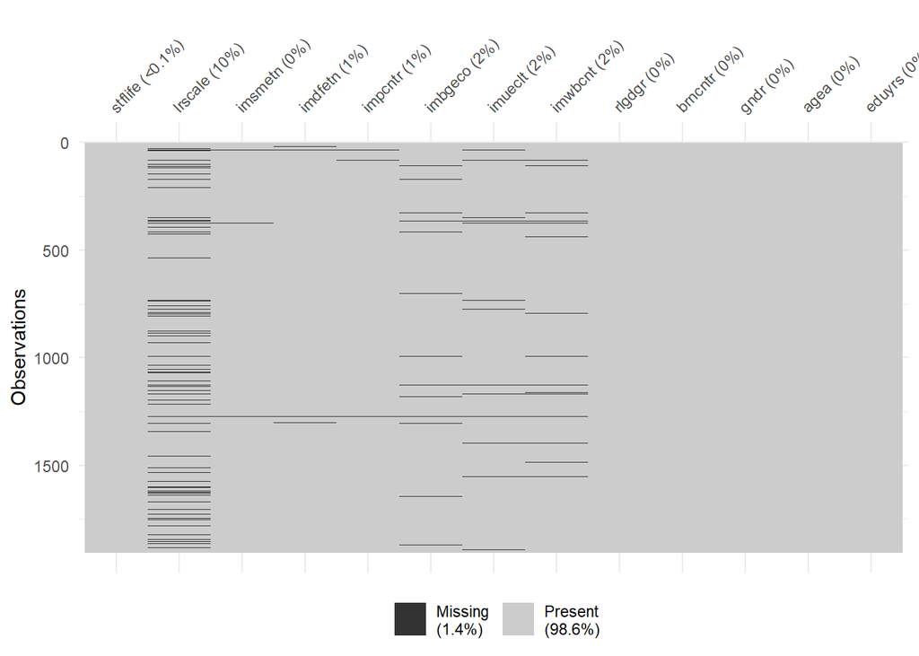

```r
vis_miss(andmed)
```

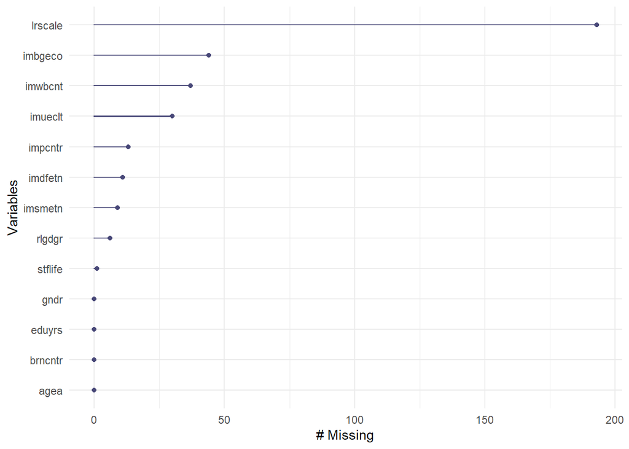

```r
gg_miss_var(andmed)
```

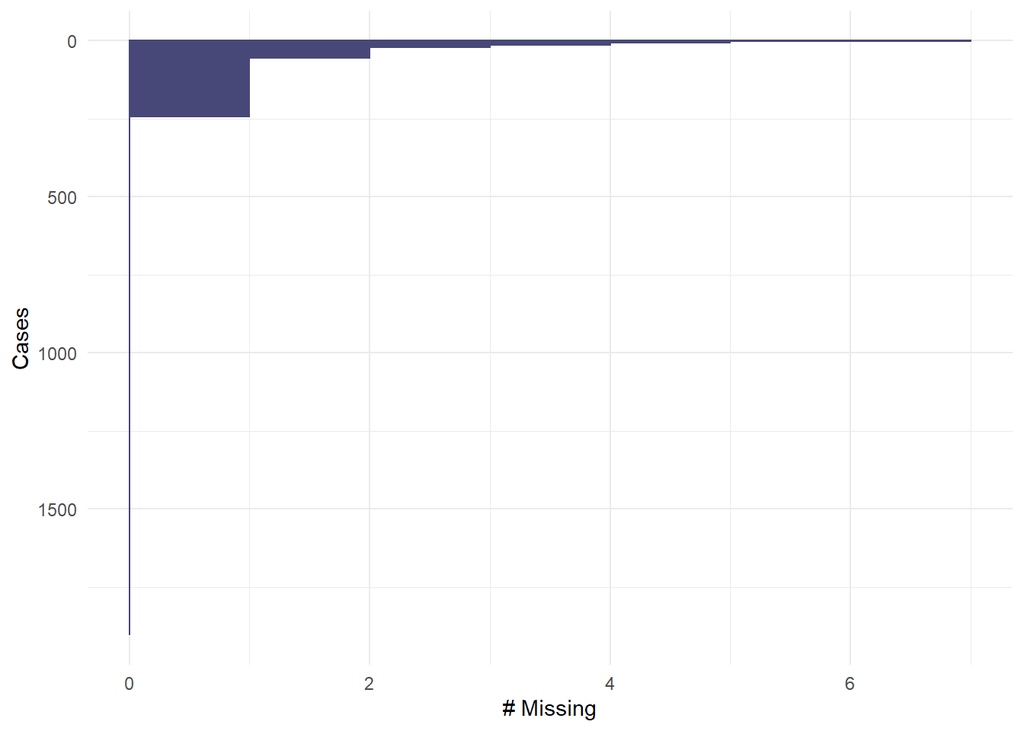

```r
gg_miss_case(andmed)
```

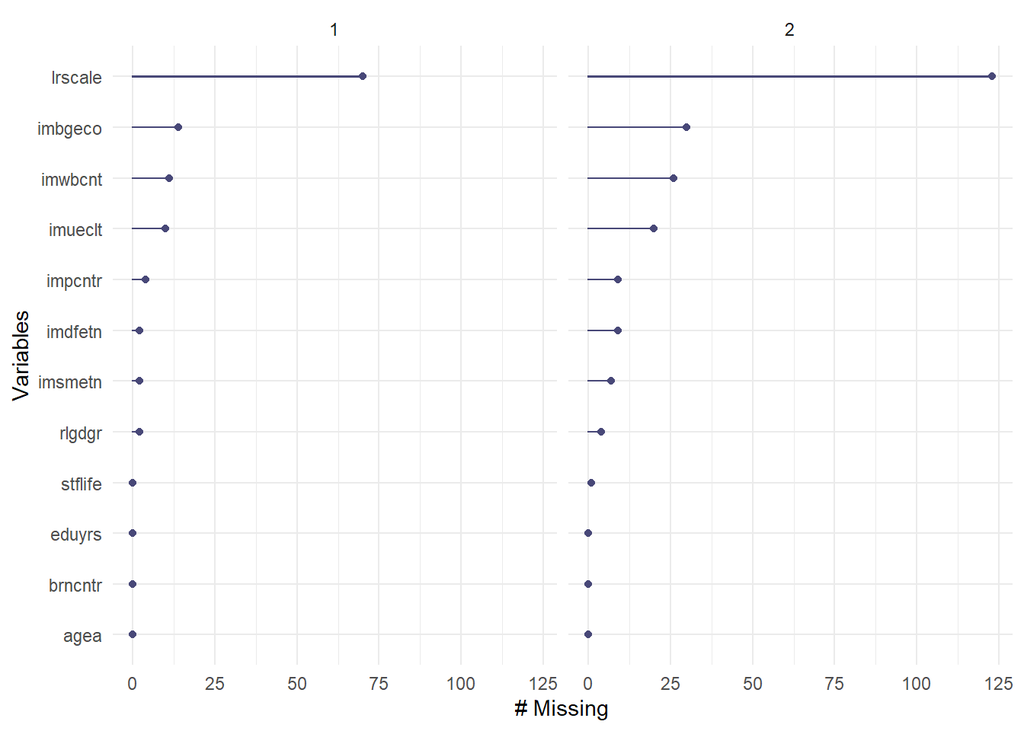

```r
gg_miss_var(andmed, facet = gndr)
```

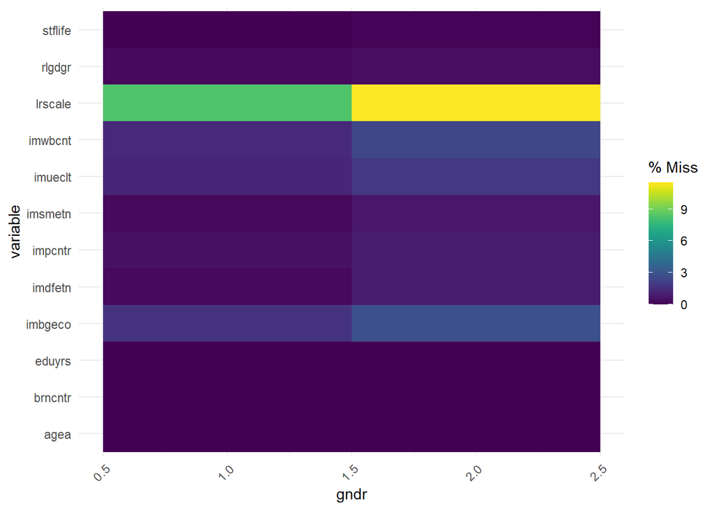

```r
gg_miss_fct(andmed, fct = gndr)
```

Eeltoodud joonised andsid sama info, mis eelnevalt arvuliselt saadud kokkuvõtted. Jooniste suurem ülevaatlikkus tuleb paremini esile siis, kui uurime lünklikkuse mustreid.

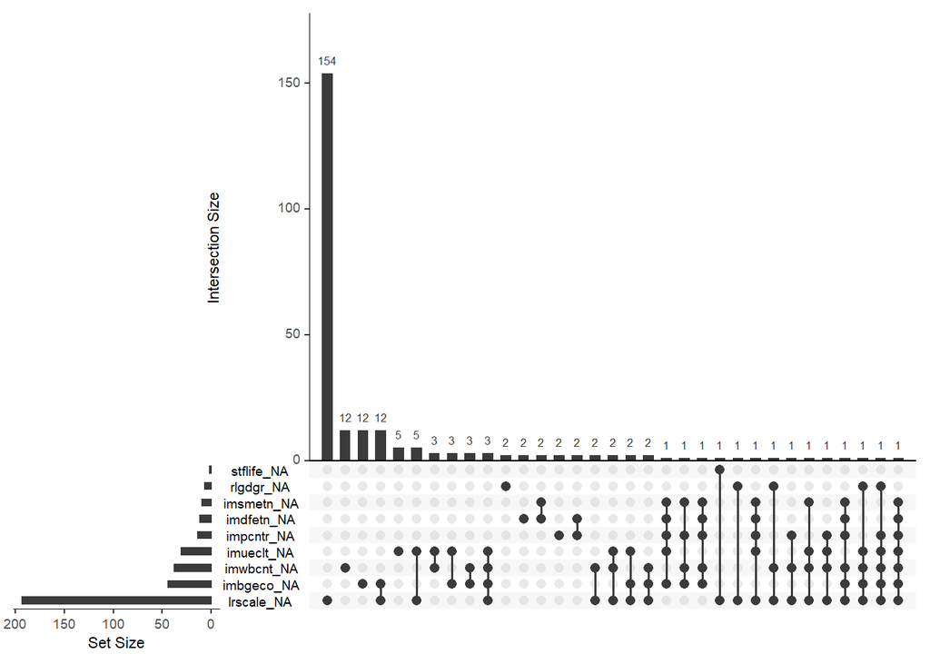

```r
gg_miss_upset(andmed, nsets = n_var_miss(andmed))
```

Kui palju täielikult mõõdetud indiviide analüüsi n-ö juurde võidaksime, kui jätaksime välja enesepaigutuse vasak-parem-skaalal?

Kui palju võidaksime juurde täielikult mõõdetud indiviide, kui seejärel jätta välja ka teine kõige suurem lünklikkusega tunnus? Kas saame selle info olemasolevalt jooniselt kätte?

## Lünkade juhuslikkus: visuaalne analüüs

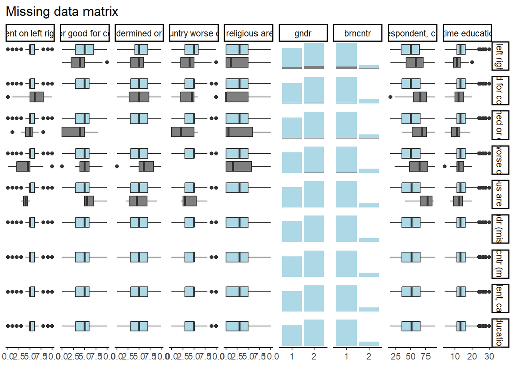

```r
andmed$gndr <- as.factor(andmed$gndr)
andmed$brncntr <- as.factor(andmed$brncntr)
missing_pairs(andmed,
              explanatory = c("lrscale", "imbgeco", "imueclt", "imwbcnt", "rlgdgr", "gndr",
                              "brncntr", "agea", "eduyrs"))
```

NB! Karpdiagrammid ei võimalda tunnuse jaotusest head ülevaadet saada, kui eristuvaid väärtuseid on vähe nagu skaalal 0-10 mõõdetud tunnuste puhul. Ka tuleb siniste ja hallide karpdiagrammide võrdlemisel silmas pidada, et enamikus tunnustest on andmelünki suhteliselt vähe (millele viitab hallide alade väiksus enamusel tulpdiagrammidest), nii et suured erinevused sama rea siniste ja hallide karpdiagrammide vahel võivad tuleneda hoopis juhuslikkusest. Teeme kohe ka mõned statistilised testid, et jälile jõuda, kas see nii võib olla, aga enne vaatame, mida siiski neist diagrammidest lünkade juhuslikkuse kohta järeldada saaksime.

Kategoriaalsete tunnuste puhul on lünklikkuse võrdlemine kategooriate lõikes ülevaatlikum, kui tulpade kõrgused on võrreldavad. Teeme selleks veidi muudetud joonise, kuigi ka eelmine versioon võib olla oluline, et märgata, kui mõnes kategoorias on väga vähe indiviide.

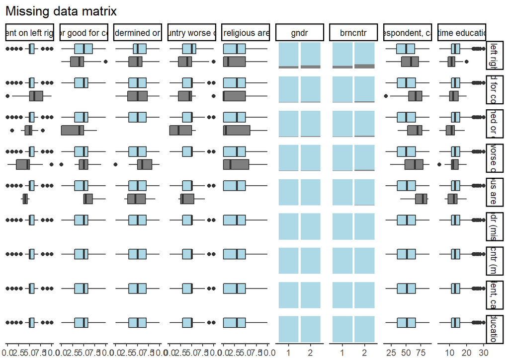

```r
missing_pairs(andmed,
              explanatory = c("lrscale", "imbgeco", "imueclt", "imwbcnt", "rlgdgr", "gndr",
                              "brncntr", "agea", "eduyrs"),
              position = "fill")
```

Mida jooniselt välja lugeda saame?

## Lünkade juhuslikkus: jaotus(parameetri)te võrdlus, statistilised testid

Vaatame lähemalt, kas vasak-parem-skaalal enesepaigutuse tunnuse lüngad on täiesti juhuslikud või mitte. Kasutades paketist `finalfit` funktsiooni `missing_compare`, arvutame teiste arvuliste tunnuste keskmised indiviidide seas, kellel on vasak-parem-skaala tunnuses valiidsed väärtused, ja nende seas, kellel on selles tunnuses andmelünk. Kategoriaalsete tunnuste puhul teeme risttabeli. Lisaks hinnatakse jaotuste erinevust statistiliste testidega. Milliste statistiliste testidega? Uuri funktsiooni abifaili, trükkides konsooli `?missing_compare`.

```r
andmed$imsmetn <- as.factor(andmed$imsmetn)
andmed$imdfetn <- as.factor(andmed$imdfetn)
andmed$impcntr <- as.factor(andmed$impcntr)
missing_compare(andmed,
                dependent = "lrscale",
                explanatory = c("imsmetn", "imdfetn", "impcntr", "imbgeco",
                                "imueclt", "imwbcnt", "rlgdgr", "gndr",
                                "brncntr", "agea", "eduyrs")) %>%
  knitr::kable(row.names=FALSE, align = c("l", "l", "r", "r", "r"))
```

| Missing data analysis: Placement on left right scale |  | Not missing | Missing | p |
| --- | --- | --- | --- | --- |
| imsmetn | 1 | 431 (91.5) | 40 (8.5) | 0.001 |
|  | 2 | 874 (91.6) | 80 (8.4) |  |
|  | 3 | 336 (84.8) | 60 (15.2) |  |
|  | 4 | 65 (87.8) | 9 (12.2) |  |
| imdfetn | 1 | 122 (94.6) | 7 (5.4) | <0.001 |
|  | 2 | 730 (94.0) | 47 (6.0) |  |
|  | 3 | 625 (87.5) | 89 (12.5) |  |
|  | 4 | 226 (82.8) | 47 (17.2) |  |
| impcntr | 1 | 88 (93.6) | 6 (6.4) | <0.001 |
|  | 2 | 568 (95.1) | 29 (4.9) |  |
|  | 3 | 634 (87.3) | 92 (12.7) |  |
|  | 4 | 414 (87.3) | 60 (12.7) |  |
| Immigration bad or good for country’s economy | Mean (SD) | 5.0 (2.3) | 3.8 (2.6) | <0.001 |
| Country’s cultural life undermined or enriched by immigrants | Mean (SD) | 5.2 (2.4) | 4.6 (2.5) | 0.001 |
| Immigrants make country worse or better place to live | Mean (SD) | 4.5 (2.1) | 3.7 (2.3) | <0.001 |
| How religious are you | Mean (SD) | 3.3 (3.1) | 2.8 (3.3) | 0.017 |
| gndr | 1 | 767 (91.6) | 70 (8.4) | 0.028 |
|  | 2 | 944 (88.5) | 123 (11.5) |  |
| brncntr | 1 | 1488 (90.6) | 154 (9.4) | 0.008 |
|  | 2 | 223 (85.1) | 39 (14.9) |  |
| Age of respondent, calculated | Mean (SD) | 50.1 (19.2) | 56.0 (19.9) | <0.001 |
| Years of full-time education completed | Mean (SD) | 13.6 (3.5) | 11.4 (3.0) | <0.001 |

Mida tulemustest järeldada saame?

Uuri ise, kas immigratsiooni tajutud mõju majandusele mõõtvas tunnuses `imbgeco` esinevad lüngad täiesti juhuslikult (MCAR) või mitte.

Mida tulemustest järeldate?

Kuidas üleüldse neid statistiliste testide tulemusi tõlgendada, kui statistilise testi eesmärk on teada saada, kas mingit erinevuse või seose esinemist saab väita mitte ainult valimis, vaid ka populatsioonis? Saab ju andmete lünklikkus esineda ainult valimis ehk küsitlusandmetes, mitte populatsioonis.

## Lünklikkus andmestikus tervikuna

Eelnev analüüs võimaldab saada üsna üksikasjaliku pildi sellest, kas ja millised tunnused on seotud lünklikkusega mingis tunnuses ja mille tõttu võivad lüngad olla andmetesse tekkinud. See on oluline info sisulisema analüüsi, mis tavaliselt andmekvaliteedi hindamisele järgneb, tulemuste tõlgendamiseks.

Samas on ka oluline hinnata analüüsitavate tunnuste kui terviku lünklikkust ehk kas need indiviidid, kellel oli vähemalt ühes tunnuses andmelünk, erinevad kuidagi täielikult mõõdetud indiviididest. See on oluline, sest kui me mingeid meetodeid andmelünkade infoga täitmiseks ei kasuta, siis tuleb mitmemõõtmelises analüüsis kõik sellised indiviidid analüüsist välja jätta.

Teeme indikaatortunnuse, mis näitab täielike vastustega indiviidide ja andmelünkadega indiviidide osakaalu andmestikus.

```r
andmed <- andmed %>%
  add_any_miss() %>%
  replace_with_na(replace = list(any_miss_all = "missing"))
```

Uurime, kas need kaks gruppi erinevad teiste tunnuste jaotuste poolest.

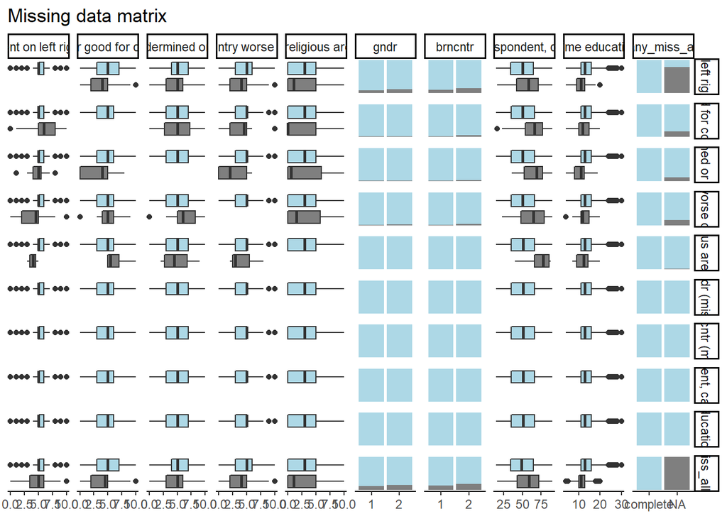

```r
missing_pairs(andmed,
              explanatory = c("lrscale", "imbgeco", "imueclt", "imwbcnt", "rlgdgr", "gndr",
                              "brncntr", "agea", "eduyrs", "any_miss_all"),
              position = "fill")
```

```r
missing_compare(andmed,
                dependent = "any_miss_all",
                explanatory = c("lrscale", "imsmetn", "imdfetn", "impcntr",
                                "imbgeco", "imueclt", "imwbcnt", "rlgdgr",
                                "gndr", "brncntr", "agea", "eduyrs")) %>%
  knitr::kable(row.names=FALSE, align = c("l", "l", "r", "r", "r"))
```

| Missing data analysis: any_miss_all |  | Not missing | Missing | p |
| --- | --- | --- | --- | --- |
| Placement on left right scale | Mean (SD) | 5.4 (1.8) | 4.8 (2.7) | 0.027 |
| imsmetn | 1 | 419 (89.0) | 52 (11.0) | 0.004 |
|  | 2 | 852 (89.3) | 102 (10.7) |  |
|  | 3 | 328 (82.8) | 68 (17.2) |  |
|  | 4 | 61 (82.4) | 13 (17.6) |  |
| imdfetn | 1 | 121 (93.8) | 8 (6.2) | <0.001 |
|  | 2 | 717 (92.3) | 60 (7.7) |  |
|  | 3 | 604 (84.6) | 110 (15.4) |  |
|  | 4 | 218 (79.9) | 55 (20.1) |  |
| impcntr | 1 | 87 (92.6) | 7 (7.4) | <0.001 |
|  | 2 | 561 (94.0) | 36 (6.0) |  |
|  | 3 | 611 (84.2) | 115 (15.8) |  |
|  | 4 | 401 (84.6) | 73 (15.4) |  |
| Immigration bad or good for country’s economy | Mean (SD) | 5.0 (2.3) | 3.9 (2.6) | <0.001 |
| Country’s cultural life undermined or enriched by immigrants | Mean (SD) | 5.2 (2.4) | 4.7 (2.7) | 0.002 |
| Immigrants make country worse or better place to live | Mean (SD) | 4.5 (2.1) | 3.6 (2.3) | <0.001 |
| How religious are you | Mean (SD) | 3.3 (3.1) | 2.8 (3.3) | 0.008 |
| gndr | 1 | 748 (89.4) | 89 (10.6) | 0.014 |
|  | 2 | 912 (85.5) | 155 (14.5) |  |
| brncntr | 1 | 1445 (88.0) | 197 (12.0) | 0.010 |
|  | 2 | 215 (82.1) | 47 (17.9) |  |
| Age of respondent, calculated | Mean (SD) | 49.8 (19.1) | 57.0 (19.7) | <0.001 |
| Years of full-time education completed | Mean (SD) | 13.6 (3.5) | 11.7 (3.2) | <0.001 |

Nagu arvata oli, erinevused on üsna selged. Seega ei saa siin rääkida lünkade täielikust juhuslikkusest, mis tähendab, et kui jätaksime lünkadega indiviidid analüüsist lihtsalt välja (mis paraku on vältimatu, kui me ei kasuta mitmest imputeerimist vm sarnast meetodit lünkade täitmiseks), siis tuleks tulemuste tõlgendamisel kindlasti arvesse võtta, kuidas lünkadega indiviidide eemaldamine tulemusi ja tulemuste esinduslikkust võib mõjutada.

Nagu eelnevalt nägime, on suurel osal lünkadega indiviididest ainult üks lünk, mis on tunnuses `lrscale`. Kas andmete esinduslikkus paraneks, kui jätaksime selle tunnuse analüüsist välja (ja seega kasvaks täielikult mõõdetud indiviidide hulk)? Püüdke eelnevat koodijuppi kasutades sellele jälile jõuda.